```r
library(dplyr)
```

```r
library(mosaic)
library(readr)
library(leaps)

UsedCars <- read.csv("~/Documents/(2) Sophomore Year/Second Semester (SPR 20)/STOR 455/CSV Files/UsedCars.csv")
```

```r
cars = subset(as.data.frame(table(UsedCars$Model)), Freq>2500)
```

```r
set.seed(12121)

FocusHatchback = sample_n(subset(UsedCars, Model=="FocusHatchback"), 200)
FocusSE = sample_n(subset(UsedCars, Model=="FocusSE"), 200)
FocusSedan = sample_n(subset(UsedCars, Model=="FocusSedan"), 200)

Focus = rbind(FocusHatchback, FocusSE, FocusSedan)
Focus$Age = 2017 - Focus$Year
```

# MODEL 3

```r
set.seed(1938575)
Fusion = sample_n(subset(UsedCars, Model=="FusionSE"), 200)
Fusion$Age = 2017 - Fusion$Year
```

### A.

```r
quadMod=lm(Price~Age+I(Age^2),data=Fusion)
summary(quadMod)
```

```
##
## Call:
## lm(formula = Price ~ Age + I(Age^2), data = Fusion)
##
## Residuals:
##    Min     1Q Median     3Q    Max
##  -4814  -1289    -44   1194   7777
##
## Coefficients:
##             Estimate Std. Error t value Pr(>|t|)
## (Intercept) 16518.04     311.79  52.979  < 2e-16 ***
## Age          -772.86     209.55  -3.688 0.000292 ***
## I(Age^2)      -42.96      29.03  -1.480 0.140566
## ---
## Signif. codes:  0 '***' 0.001 '**' 0.01 '*' 0.05 '.' 0.1 ' ' 1
##
## Residual standard error: 2066 on 197 degrees of freedom
## Multiple R-squared:  0.4014, Adjusted R-squared:  0.3954
## F-statistic: 66.06 on 2 and 197 DF,  p-value: < 2.2e-16
```

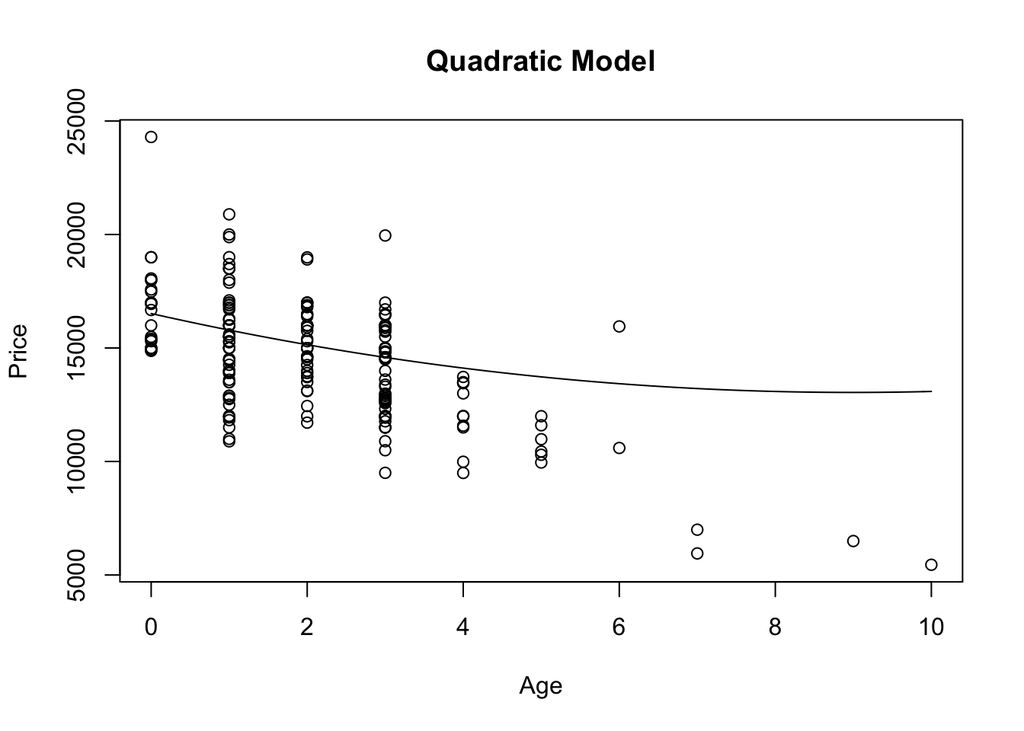

```r
plot(Price~Age,main="Quadratic Model",data=Fusion)
curve(16518.04-772.86*x+42.96*x^2,add=TRUE)
```

### B.

```r
summary(quadMod)
```

```
##
## Call:
## lm(formula = Price ~ Age + I(Age^2), data = Fusion)
##
## Residuals:
##    Min     1Q Median     3Q    Max
##  -4814  -1289    -44   1194   7777
##
## Coefficients:
##             Estimate Std. Error t value Pr(>|t|)
## (Intercept) 16518.04     311.79  52.979  < 2e-16 ***
## Age          -772.86     209.55  -3.688 0.000292 ***
## I(Age^2)      -42.96      29.03  -1.480 0.140566
## ---
## Signif. codes:  0 '***' 0.001 '**' 0.01 '*' 0.05 '.' 0.1 ' ' 1
##
## Residual standard error: 2066 on 197 degrees of freedom
## Multiple R-squared:  0.4014, Adjusted R-squared:  0.3954
## F-statistic: 66.06 on 2 and 197 DF,  p-value: < 2.2e-16
```

Null Hypothesis: coefficients = 0, no terms of ‘Age’ relate to ‘Price’ Alternative Hypothesis: coefficients /= 0, at least of term of ‘Age’ relates to ‘Price’

The variable ‘Age’ has a p-value 0.000292. So, we can reject the null hypothesis and conclude that some term involving ‘Age’ is significant in predicting ‘Age’.

### C.

```r
threeYearCar = data.frame(Age = 3)
predict.lm(quadMod, threeYearCar, interval = "prediction", level = .9)
```

```
##        fit      lwr      upr
## 1 13812.84 10383.44 17242.24
```

Based on the prediction interval, most 3 year old Fusions would be contained within the price range [10383.44 , 17242.24] with 90% confidence.

### D.

```r
16518.04-772.86*(8.995)+42.96*(8.995)^2
```

```
## [1] 13042.06
```

For (Age = x) and (Price = y)…

### F.

```r
cubicMod=lm(Price~Age+I(Age^2)+I(Age^3),data=Fusion)
summary(cubicMod)
```

```
##
## Call:
## lm(formula = Price ~ Age + I(Age^2) + I(Age^3), data = Fusion)
##
## Residuals:
##     Min      1Q  Median      3Q     Max
## -4839.0 -1295.2     6.2  1158.0  7869.2
##
## Coefficients:
##              Estimate Std. Error t value Pr(>|t|)
## (Intercept) 16425.848    375.526  43.741   <2e-16 ***
## Age          -599.785    443.945  -1.351    0.178
## I(Age^2)     -103.949    140.877  -0.738    0.461
## I(Age^3)        4.897     11.067   0.442    0.659
## ---
## Signif. codes:  0 '***' 0.001 '**' 0.01 '*' 0.05 '.' 0.1 ' ' 1
##
## Residual standard error: 2070 on 196 degrees of freedom
## Multiple R-squared:  0.402,  Adjusted R-squared:  0.3929
## F-statistic: 43.93 on 3 and 196 DF,  p-value: < 2.2e-16
```

```r
quarticMod=lm(Price~Age+I(Age^2)+I(Age^3)+I(Age^4),data=Fusion)
summary(quarticMod)
```

```
##
## Call:
## lm(formula = Price ~ Age + I(Age^2) + I(Age^3) + I(Age^4), data = Fusion)
##
## Residuals:
##    Min     1Q Median     3Q    Max
##  -4687  -1331    -31   1211   7635
##
## Coefficients:
##              Estimate Std. Error t value Pr(>|t|)
## (Intercept) 16659.896    414.389  40.203   <2e-16 ***
## Age         -1380.273    737.376  -1.872   0.0627 .
## I(Age^2)      380.697    392.069   0.971   0.3328
## I(Age^3)      -90.746     73.066  -1.242   0.2157
## I(Age^4)        5.577      4.212   1.324   0.1870
## ---
## Signif. codes:  0 '***' 0.001 '**' 0.01 '*' 0.05 '.' 0.1 ' ' 1
##
## Residual standard error: 2066 on 195 degrees of freedom
## Multiple R-squared:  0.4074, Adjusted R-squared:  0.3952
## F-statistic: 33.51 on 4 and 195 DF,  p-value: < 2.2e-16
```

```r
anova(cubicMod, quadMod)
```

```
## Analysis of Variance Table
##
## Model 1: Price ~ Age + I(Age^2) + I(Age^3)
## Model 2: Price ~ Age + I(Age^2)
##   Res.Df       RSS Df Sum of Sq      F Pr(>F)
## 1    196 839633004
## 2    197 840471762 -1   -838758 0.1958 0.6586
```

```r
anova(quarticMod, quadMod)
```

```
## Analysis of Variance Table
##
## Model 1: Price ~ Age + I(Age^2) + I(Age^3) + I(Age^4)
## Model 2: Price ~ Age + I(Age^2)
##   Res.Df       RSS Df Sum of Sq     F Pr(>F)
## 1    195 832149908
## 2    197 840471762 -2  -8321854 0.975  0.379
```

Looking at the Adjusted R-squared values, there is no real distinction between the fit of the quadratic, cubic, and quartic models. The quadratic techincally has the best fit, but the differences are so miniscule that there is no significant advantage in terms of fit.

Adjusted R-Squared Values:

0.3954 (quadratic), 0.3929 (cubic), 0.3952 (quartic)

Also, looking at the anova tests does not show any significant improvements by introducing cubic or quartic terms.

# MODEL 4

### A.

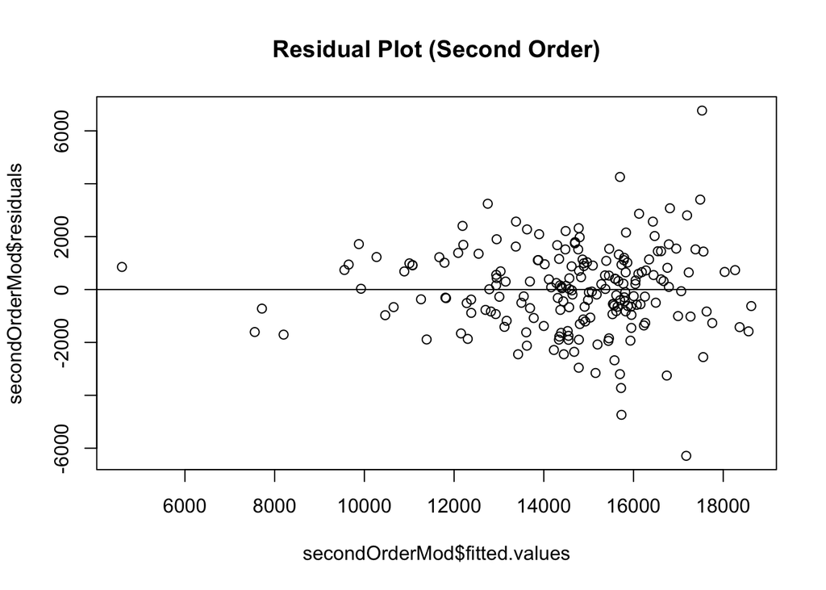

```r
secondOrderMod = lm(Price~Age+Mileage+I(Age^2)+I(Mileage^2)+Age*Mileage,data=Fusion)
plot(secondOrderMod$residuals~secondOrderMod$fitted.values, main = "Residual Plot (Second Order)")
abline(0,0)
```

The residuals vary nicely around the mean, so we can say the model has zero mean. There is some fanning towards the upper limit of the model, which suggests some degree of non-linearity, but overall it tends to vary uniformally about the mean.

### B.

```r
summary(secondOrderMod)
```

```
##
## Call:
## lm(formula = Price ~ Age + Mileage + I(Age^2) + I(Mileage^2) +
##     Age * Mileage, data = Fusion)
##
## Residuals:
##     Min      1Q  Median      3Q     Max
## -6287.5  -929.2    25.8   991.7  6766.9
##
## Coefficients:
##                Estimate Std. Error t value Pr(>|t|)
## (Intercept)   1.883e+04  3.834e+02  49.113  < 2e-16 ***
## Age          -1.682e+02  1.797e+02  -0.936  0.35061
## Mileage      -1.057e-01  1.386e-02  -7.620 1.09e-12 ***
## I(Age^2)     -2.349e+01  3.600e+01  -0.652  0.51488
## I(Mileage^2)  4.860e-07  1.491e-07   3.259  0.00132 **
## Age:Mileage  -3.858e-03  4.122e-03  -0.936  0.35047
## ---
## Signif. codes:  0 '***' 0.001 '**' 0.01 '*' 0.05 '.' 0.1 ' ' 1
##
## Residual standard error: 1604 on 194 degrees of freedom
## Multiple R-squared:  0.6446, Adjusted R-squared:  0.6355
## F-statistic: 70.38 on 5 and 194 DF,  p-value: < 2.2e-16
```

```r
anova(secondOrderMod)
```

```
## Analysis of Variance Table
##
## Response: Price
##               Df    Sum Sq   Mean Sq  F value    Pr(>F)
## Age            1 554338953 554338953 215.5150 < 2.2e-16 ***
## Mileage        1 308643080 308643080 119.9937 < 2.2e-16 ***
## I(Age^2)       1   4119063   4119063   1.6014 0.2072223
## I(Mileage^2)   1  35797970  35797970  13.9175 0.0002508 ***
## Age:Mileage    1   2253152   2253152   0.8760 0.3504696
## Residuals    194 498999015   2572160
## ---
## Signif. codes:  0 '***' 0.001 '**' 0.01 '*' 0.05 '.' 0.1 ' ' 1
```

Null Hypothesis: coefficients = 0 (Beta = 0), none of the terms relate to ‘Price’ Alternative Hypothesis: coefficients /= 0 (Beta /= 0), at least one of the terms relates to ‘Price’

With a p-value < 2.2e-16, we can reject the null hypothesis. So, we can conclude that some variation of the terms ‘Age’ or ‘Mileage’ are significant indicators of ‘Price’.

### C.

```r
secondOrderRed = lm(Price~Age+Mileage, data=Fusion)
anova(secondOrderRed, secondOrderMod)
```

```
## Analysis of Variance Table
##
## Model 1: Price ~ Age + Mileage
## Model 2: Price ~ Age + Mileage + I(Age^2) + I(Mileage^2) + Age * Mileage
##   Res.Df       RSS Df Sum of Sq     F   Pr(>F)
## 1    197 541169200
## 2    194 498999015  3  42170185 5.465 0.001259 **
## ---
## Signif. codes:  0 '***' 0.001 '**' 0.01 '*' 0.05 '.' 0.1 ' ' 1
```

Null Hypothesis: coefficients = 0 (Beta = 0), none of the second order terms relate to ‘Price’ Alternative Hypothesis: coefficient /= 0 (Beta /= 0), at least one of the second order terms relates to ‘Price’

‘Age^2’ has p-value = 0.51488. ‘Mileage^2’ has p-value = 0.00132. ‘Age * Mileage’ has p-value = 0.35047.

Since ‘Mileage^2’ has a p-value < 0.05, we can reject the null hypothesis. Also, based on the anova test (p-value of 0.001259), the second order terms seem to have some importance in predicting ‘Price’.

### D.

```r
secondOrderMil = lm(Price~Mileage+I(Mileage^2)+I(Mileage*Age), data=Fusion)
anova(secondOrderMil, secondOrderMod)
```

```
## Analysis of Variance Table
##
## Model 1: Price ~ Mileage + I(Mileage^2) + I(Mileage * Age)
## Model 2: Price ~ Age + Mileage + I(Age^2) + I(Mileage^2) + Age * Mileage
##   Res.Df       RSS Df Sum of Sq      F Pr(>F)
## 1    196 503621194
## 2    194 498999015  2   4622179 0.8985 0.4089
```

Null Hypothesis: coefficients = 0 (Beta = 0), none of the terms involving ‘Mileage’ relate to ‘Price’ Alternative Hypothesis: coefficient /= 0 (Beta /= 0), at least one of the terms involving ‘Mileage’ relates to ‘Price’

‘Mileage’ has p-value = 1.09e-12. ‘Mileage^2’ has p-value = 0.00132. ‘Age * Mileage’ has p-value = 0.35047.

# MODEL 5

### A.

```r
multiMod=lm(Price~Age+Mileage+Model,data=Focus)
```

### B.

```r
summary(multiMod)
```

```
##
## Call:
## lm(formula = Price ~ Age + Mileage + Model, data = Focus)
##
## Residuals:
##     Min      1Q  Median      3Q     Max
## -5101.5 -1158.1  -328.5   730.9 22705.4
##
## Coefficients:
##                   Estimate Std. Error t value Pr(>|t|)
## (Intercept)      1.633e+04  2.250e+02  72.596  < 2e-16 ***
## Age             -5.113e+02  7.693e+01  -6.647 6.79e-11 ***
## Mileage         -5.482e-02  4.854e-03 -11.293  < 2e-16 ***
## ModelFocusSE    -1.305e+03  2.204e+02  -5.921 5.41e-09 ***
## ModelFocusSedan -1.569e+03  2.188e+02  -7.169 2.24e-12 ***
## ---
## Signif. codes:  0 '***' 0.001 '**' 0.01 '*' 0.05 '.' 0.1 ' ' 1
##
## Residual standard error: 2181 on 595 degrees of freedom
## Multiple R-squared:  0.4416, Adjusted R-squared:  0.4379
## F-statistic: 117.6 on 4 and 595 DF,  p-value: < 2.2e-16
```

```r
anova(multiMod)
```

```
## Analysis of Variance Table
##
## Response: Price
##            Df     Sum Sq    Mean Sq F value    Pr(>F)
## Age         1 1337134573 1337134573 281.219 < 2.2e-16 ***
## Mileage     1  622169593  622169593 130.851 < 2.2e-16 ***
## Model       2  278273530  139136765  29.262 7.556e-13 ***
## Residuals 595 2829099577    4754789
## ---
## Signif. codes:  0 '***' 0.001 '**' 0.01 '*' 0.05 '.' 0.1 ' ' 1
```

Null Hypothesis: coefficients = 0 (Beta = 0), none of the ‘Model’ terms relate to ‘Price’ Alternative Hypothesis: coefficients /= 0 (Beta /= 0), at least one of the ‘Model’ terms relates to ‘Price’

According to the anova test, the p-value for the ‘Model’ term is 7.556e-13 (< 0.05).

So, we can reject the null hypothesis and conclude that ‘Model’ does have some importance in predicting ‘Price’.

### C.

```r
multiMod2=lm(Price~Age+Mileage+Model+Age*Model+Mileage*Model, data=Focus)
```

### D.

```r
summary(multiMod2)
```

```
##
## Call:
## lm(formula = Price ~ Age + Mileage + Model + Age * Model + Mileage *
##     Model, data = Focus)
##
## Residuals:
##     Min      1Q  Median      3Q     Max
## -5205.8 -1165.6  -328.1   718.9 22590.3
##
## Coefficients:
##                           Estimate Std. Error t value Pr(>|t|)
## (Intercept)              1.648e+04  3.768e+02  43.731  < 2e-16 ***
## Age                     -4.533e+02  1.553e+02  -2.918  0.00365 **
## Mileage                 -6.202e-02  8.316e-03  -7.457 3.16e-13 ***
## ModelFocusSE            -1.539e+03  4.879e+02  -3.155  0.00169 **
## ModelFocusSedan         -1.750e+03  5.712e+02  -3.064  0.00229 **
## Age:ModelFocusSE        -8.875e+01  1.890e+02  -0.469  0.63891
## Age:ModelFocusSedan     -1.047e+02  2.353e+02  -0.445  0.65660
## Mileage:ModelFocusSE     1.102e-02  1.149e-02   0.959  0.33779
## Mileage:ModelFocusSedan  1.087e-02  1.240e-02   0.877  0.38090
## ---
## Signif. codes:  0 '***' 0.001 '**' 0.01 '*' 0.05 '.' 0.1 ' ' 1
##
## Residual standard error: 2186 on 591 degrees of freedom
## Multiple R-squared:  0.4427, Adjusted R-squared:  0.4352
## F-statistic: 58.69 on 8 and 591 DF,  p-value: < 2.2e-16
```

```r
anova(multiMod2)
```

```
## Analysis of Variance Table
##
## Response: Price
##                Df     Sum Sq    Mean Sq  F value    Pr(>F)
## Age             1 1337134573 1337134573 279.8708 < 2.2e-16 ***
## Mileage         1  622169593  622169593 130.2241 < 2.2e-16 ***
## Model           2  278273530  139136765  29.1222 8.659e-13 ***
## Age:Model       2      33311      16656   0.0035    0.9965
## Mileage:Model   2    5454248    2727124   0.5708    0.5654
## Residuals     591 2823612017    4777685
## ---
## Signif. codes:  0 '***' 0.001 '**' 0.01 '*' 0.05 '.' 0.1 ' ' 1
```

Null Hypothesis: coefficient = 0 (Beta = 0), none of the ‘Model’ terms relate to ‘Price’ Alternative Hypothesis: at least one coefficient /= 0 (Beta /= 0), at least one of the ‘Model’ terms relates to ‘Price’

Since the ‘Model’ term produces a p-value < 0.05, we can reject the null hypothesis. However, the interaction terms seem to be less significant in predicting ‘Price’.

### E.

```r
anova(multiMod, multiMod2)
```

```
## Analysis of Variance Table
##
## Model 1: Price ~ Age + Mileage + Model
## Model 2: Price ~ Age + Mileage + Model + Age * Model + Mileage * Model
##   Res.Df        RSS Df Sum of Sq      F Pr(>F)
## 1    595 2829099577
## 2    591 2823612017  4   5487559 0.2871 0.8864
```

For explanation, Model A = multiMod and Model B = multiMod2.

Model A is nested within Model B, with Model B incorporating the interaction terms of ‘Age * Model’ and ‘Mileage * Model’. Model B assumes that there is some added benefit of including the interactions between multiple factors. Model B also assumes that the ‘Model’ of the car has a great impact on predicting ‘Price’, which would only make a significant impact if the ‘Model’ is vintage/worth a lot of money. In this case, the ‘Mileage’ would not matter and the ‘Age’ might increase ‘Price’ based on the interaction terms. In most cases though, the interaction terms would not have very much impact since most models of car decrease in value as they age and gain mileage (eveidenced by the above test with p-value 0.8864). Model A assumes there is a relationship between ‘Age’, ‘Mileage’, and ‘Model’ in predicting ‘Price’. Model A, in context, would not necessarily account for or be well equipped in predicting these cars that are worth more as they age (where ‘Model’ matters more).